# Getting Started with PyFixest

In a first step, we load the module and some example data:

```python
from pyfixest import Fixest
from pyfixest.utils import get_data

data = get_data()
data.head()
```

from pyfixest import Fixest from pyfixest.utils import get_data data = get_data() data.head()

|  | Y | X1 | X2 | X3 | X4 | X5 | group_id | Y2 | Z1 | Z2 | Z3 |
| --- | --- | --- | --- | --- | --- | --- | --- | --- | --- | --- | --- |
| 0 | NaN | 0.471435 | 1 | 2 | 9 | -0.708356 | 9 | 0.234702 | -0.045599 | -0.392056 | 0.415907 |
| 1 | -6.409870 | NaN | 4 | 0 | 9 | -1.505502 | 22 | -6.627028 | NaN | 3.876138 | -0.623901 |
| 2 | -2.333356 | 1.150036 | 2 | 4 | 8 | -0.788021 | 20 | -2.746546 | 0.190001 | 2.624511 | 3.131796 |
| 3 | -7.160509 | 0.002118 | 4 | 1 | 6 | -0.663068 | 6 | -6.161993 | 1.558855 | 5.863402 | 1.516510 |
| 4 | -5.109250 | -0.202646 | 4 | 5 | 5 | -0.880477 | 11 | -4.958727 | -0.681674 | 4.992367 | 5.161129 |

## OLS Estimation

We then initiate an object of type `Fixest`.

```python
fixest = Fixest(data = data)
```

fixest = Fixest(data = data)

For this object, we can now estimate a fixed effects regression via the `.feols()` method. `.feols()` has two arguments: a two-sided model formula, and the type of inference.

```python
fixest.feols("Y~X1 | X2", vcov = "HC1")
```

fixest.feols("Y~X1 | X2", vcov = "HC1")

```
<pyfixest.fixest.Fixest at 0x1eba45ae140>
```

The first part of the formula contains the dependent variable and "regular" covariates, while the second part contains fixed effects.

Estimation results can be accessed via a `.summary()` or `.tidy()` method:

```python
fixest.summary()
```

fixest.summary()

```
###

Model:  OLS
Dep. var.:  Y
Fixed effects:  X2
Inference:  HC1
Observations:  1998

 Estimate  Std. Error  t value  Pr(>|t|)   ci_l  ci_u
   -0.066       0.043   -1.534     0.125 -0.151 0.018
---
RMSE: 1.843  Adj. R2: 0.001  Adj. R2 Within: 0.001
```

## Standard Errors and Inference

Supported covariance types are "iid", "HC1-3", CRV1 and CRV3 (one-way clustering). Inference can be adjusted "on-the-fly" via the `.vcov()` method:

```python
fixest.vcov({'CRV1':'group_id'}).summary()
```

fixest.vcov({'CRV1':'group_id'}).summary()

```
###

Model:  OLS
Dep. var.:  Y
Fixed effects:  X2
Inference:  {'CRV1': 'group_id'}
Observations:  1998

 Estimate  Std. Error  t value  Pr(>|t|)   ci_l  ci_u
   -0.066       0.036   -1.839     0.078 -0.141 0.008
---
RMSE: 1.843  Adj. R2: 0.001  Adj. R2 Within: 0.001
```

It is also possible to run a wild (cluster) bootstrap after estimation (via the [wildboottest module](https://github.com/s3alfisc/wildboottest), only for Python versions smaller than `3.11`):

```python
fixest = Fixest(data = data)
fixest.feols("Y~ csw(X1, X2, X3)", vcov = {"CRV1":"group_id"})
fixest.wildboottest(param = "X1", B = 999)
```

fixest = Fixest(data = data) fixest.feols("Y~ csw(X1, X2, X3)", vcov = {"CRV1":"group_id"}) fixest.wildboottest(param = "X1", B = 999)

| fml | param | t value | Pr(>\|t\|) |
| --- | --- | --- | --- |
| Y~X1 | X1 | -0.206923 | 0.842843 |
| Y~X1+X2 | X1 | -1.841861 | 0.072072 |
| Y~X1+X2+X3 | X1 | -2.917392 | 0.007007 |

Note that the wild bootstrap currently does not support fixed effects in the regression model. Supporting fixed effects is work in progress.

## IV Estimation

It is also possible to estimate instrumental variable models with *one* endogenous variable and (potentially multiple) instruments:

```python
fixest = Fixest(data = data)
fixest.feols("Y2~ 1 | X2 | X1 ~ Z1 + Z2")
fixest.summary()
```

fixest = Fixest(data = data) fixest.feols("Y2~ 1 | X2 | X1 ~ Z1 + Z2") fixest.summary()

```
###

Model:  IV
Dep. var.:  Y2
Fixed effects:  X2
Inference:  {'CRV1': 'X2'}
Observations:  1999

 Estimate  Std. Error  t value  Pr(>|t|)   ci_l  ci_u
    0.065       0.036    1.779      0.15 -0.036 0.165
---
```

If the model does not contain any fixed effects, just drop the second part of the formula above:

```python
fixest.feols("Y~ 1 | X1 ~ Z1 + Z2")
```

fixest.feols("Y~ 1 | X1 ~ Z1 + Z2")

```
<pyfixest.fixest.Fixest at 0x1eb83807610>
```

IV estimation with multiple endogenous variables and multiple estimation syntax is currently not supported. The syntax is "depvar ~ exog.vars | fixef effects | endog.vars ~ instruments".

## Poisson Regression

With version `0.8.4`, it is possible to estimate Poisson Regressions (not yet on PyPi):

```python
import pyfixest as pf
from pyfixest.utils import get_poisson_data

pdata = get_poisson_data()
fixest = Fixest(data = pdata)
fixest.fepois("Y~X1 | X2+X3+X4", vcov = {'CRV1':'X4'})

fixest.summary()
```

import pyfixest as pf from pyfixest.utils import get_poisson_data pdata = get_poisson_data() fixest = Fixest(data = pdata) fixest.fepois("Y~X1 | X2+X3+X4", vcov = {'CRV1':'X4'}) fixest.summary()

```
###

Model:  Poisson
Dep. var.:  Y
Fixed effects:  X2+X3+X4
Inference:  {'CRV1': 'X4'}
Observations:  1000

 Estimate  Std. Error  t value  Pr(>|t|)  ci_l  ci_u
    0.874       0.037    23.78       0.0 0.802 0.946
---
```

## Multiple Estimation

`PyFixest` supports a range of multiple estimation functionality: `sw`, `sw0`, `csw`, `csw0`, and multiple dependent variables. Note that every new call of `.feols()` attaches new regression results the `Fixest` object.

```python
fixest = Fixest(data)
fixest.feols("Y~X1 | csw0(X3, X4)", vcov = "HC1").summary()
```

fixest = Fixest(data) fixest.feols("Y~X1 | csw0(X3, X4)", vcov = "HC1").summary()

```
###

Model:  OLS
Dep. var.:  Y
Inference:  HC1
Observations:  1998

 Estimate  Std. Error  t value  Pr(>|t|)   ci_l   ci_u
   -1.658       0.056  -29.585     0.000 -1.768 -1.549
   -0.011       0.057   -0.187     0.852 -0.123  0.102
---
RMSE: 2.501  Adj. R2: -0.001  Adj. R2 Within: -0.001
###

Model:  OLS
Dep. var.:  Y
Fixed effects:  X3
Inference:  HC1
Observations:  1998

 Estimate  Std. Error  t value  Pr(>|t|)   ci_l  ci_u
   -0.016       0.052   -0.308     0.758 -0.118 0.086
---
RMSE: 2.294  Adj. R2: -0.0  Adj. R2 Within: -0.0
###

Model:  OLS
Dep. var.:  Y
Fixed effects:  X3+X4
Inference:  HC1
Observations:  1998

 Estimate  Std. Error  t value  Pr(>|t|)   ci_l  ci_u
     0.03       0.045    0.666     0.506 -0.059 0.119
---
RMSE: 1.937  Adj. R2: -0.0  Adj. R2 Within: -0.0
```

You can access an individual model by its name - i.e. a formula - via the `all_fitted_models` attribure.

```python
fixest.all_fitted_models["Y~X1"].tidy()
```

fixest.all_fitted_models["Y~X1"].tidy()

| coefnames | Estimate | Std. Error | t value | Pr(>\|t\|) | ci_l | ci_u |
| --- | --- | --- | --- | --- | --- | --- |
| Intercept | -1.658471 | 0.056058 | -29.584993 | 0.000000 | -1.768409 | -1.548533 |
| X1 | -0.010746 | 0.057483 | -0.186937 | 0.851729 | -0.123478 | 0.101987 |

or equivalently via the `fetch_model` method:

```python
fixest.fetch_model(0).tidy()
```

fixest.fetch_model(0).tidy()

```
Model:  Y~X1
```

| coefnames | Estimate | Std. Error | t value | Pr(>\|t\|) | ci_l | ci_u |
| --- | --- | --- | --- | --- | --- | --- |
| Intercept | -1.658471 | 0.056058 | -29.584993 | 0.000000 | -1.768409 | -1.548533 |
| X1 | -0.010746 | 0.057483 | -0.186937 | 0.851729 | -0.123478 | 0.101987 |

Here, `0` simply fetches the first model stored in the `all_fitted_models` dictionary, `1` the second etc.

## TWFE Event Study

To conclude this intro, we estimate an event study from an example of the the [LOST](https://lost-stats.github.io/Model_Estimation/Research_Design/event_study.html) library of statistical techniques.

```python
import pandas as pd
import numpy as np
from pyfixest import Fixest

# Read in data
df = pd.read_csv("https://raw.githubusercontent.com/LOST-STATS/LOST-STATS.github.io/master/Model_Estimation/Data/Event_Study_DiD/bacon_example.csv")

df['time_to_treat'] = (df['year'] - df['_nfd'] ).fillna(0).astype(int)
df['time_to_treat'] = pd.Categorical(df.time_to_treat, np.sort(df.time_to_treat.unique()))
df['treat'] = np.where(pd.isna(df['_nfd']), 0, 1)

fixest = Fixest(df)
fml = 'asmrs ~ i(time_to_treat, treat, ref = -1) + csw(pcinc, asmrh, cases) | stfips + year'
fixest.feols(fml, vcov = {'CRV1':'stfips'})
fixest.iplot()
```

import pandas as pd import numpy as np from pyfixest import Fixest # Read in data df = pd.read_csv("https://raw.githubusercontent.com/LOST-STATS/LOST-STATS.github.io/master/Model_Estimation/Data/Event_Study_DiD/bacon_example.csv") df['time_to_treat'] = (df['year'] - df['_nfd'] ).fillna(0).astype(int) df['time_to_treat'] = pd.Categorical(df.time_to_treat, np.sort(df.time_to_treat.unique())) df['treat'] = np.where(pd.isna(df['_nfd']), 0, 1) fixest = Fixest(df) fml = 'asmrs ~ i(time_to_treat, treat, ref = -1) + csw(pcinc, asmrh, cases) | stfips + year' fixest.feols(fml, vcov = {'CRV1':'stfips'}) fixest.iplot()

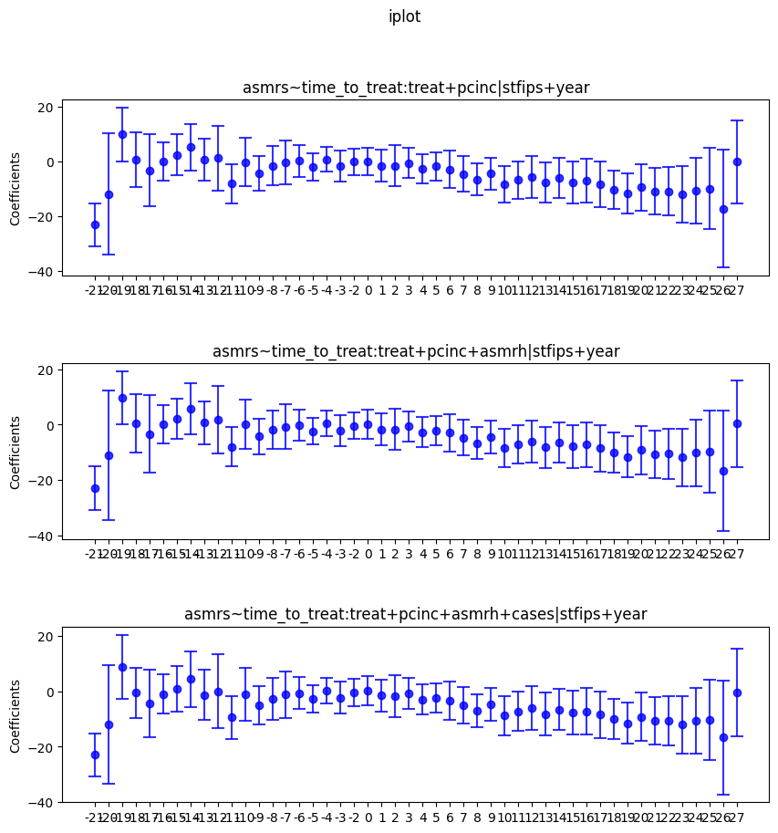

« Previous Next »